# Memory networks: states that remember how you got there

honets

2026-08-26

> Each section below is one verb, worked end to end on the same data. The sections run in order in a single R session, so later ones may reuse objects the earlier ones built.

## build_hon(): higher-order networks from sequences

### The analytic question

A transition network answers “what follows what”. It cannot answer “what follows what, *given how you got here*” — because a first-order node is just a state, with no memory of the path that reached it.

`build_hon()` builds a network whose nodes carry that memory. A node like `Specify -> Command` is the state `Command` together with the fact that `Specify` preceded it, and it keeps its own continuation distribution. The network only creates such a node when the evidence justifies it: the BuildHON+ rule of Xu, Wickramarathne & Chawla (2016) adds a higher-order context **only if** its continuation distribution differs meaningfully from the lower-order one it would otherwise inherit.

```r
library(honets)
```

```r
library(cograph)
```

The data are `human_long`: 10,796 coded human turns from 429 human-AI pair-programming sessions, nine action codes.

### Building one

Long-format event data goes in directly — name the action, actor and time columns and `build_hon()` does the splitting.

```r
hon <- build_hon(human_long,
                 action = "code", actor = "session_id", time = "timestamp",
                 max_order = 3, min_freq = 5)
hon
```

```
Higher-Order Network (HON)
  Nodes:        233 (9 first-order states)
  Edges:        819
  Max order:    3 (requested 3)
  Min freq:     5
  Trajectories: 425
```

Nine states, but **233 nodes**. The extra 224 are memory contexts that earned their place. `max_order = 3` is a ceiling, not a target: the rule extraction stops promoting a context as soon as the higher order stops paying.

`summary()` adds the order breakdown:

```r
summary(hon)
```

```
Higher-Order Network (HON) Summary
  Nodes: 233 | Edges: 819 | Trajectories: 425
  First-order states: Command, Correct, Frustrate, Inquire, Interrupt, Refine, Request, Specify, Verify
  Max order observed: 3 (requested: 3)
  Min frequency: 5
  Node order distribution:
    Order 1: 9 nodes
    Order 2: 74 nodes
    Order 3: 150 nodes
```

### Reading the rules

`as.data.frame()` is the accessor. Each row is one extracted rule: a source context, a target state, how often it occurred, and the conditional probability.

```r
as.data.frame(hon, sort_by = "count", top = 6)
```

```
                  path    from        to count probability from_order to_order
1   Specify -> Command Specify   Command   740   0.2640971          1        2
2   Request -> Specify Request   Specify   630   0.6158358          1        2
3   Command -> Specify Command   Specify   549   0.2767137          1        2
4   Specify -> Specify Specify   Specify   481   0.1716631          1        2
5   Command -> Command Command   Command   475   0.2394153          1        2
6 Specify -> Interrupt Specify Interrupt   466   0.1663098          1        2
```

Read the first row as: *of all the times `Specify` was followed by something, 26.4% of the time it was `Command`* — 740 occurrences. That one is first-order (`from_order = 1`), which is the baseline the higher-order rules have to beat.

The genuinely higher-order rules are the ones with `from_order >= 2`:

```r
as.data.frame(hon, order_min = 2, sort_by = "count", top = 6)
```

```
                                      path                          from
1            Specify -> Command -> Specify            Specify -> Command
2            Command -> Request -> Specify            Command -> Request
3            Specify -> Command -> Request            Specify -> Command
4          Request -> Specify -> Interrupt            Request -> Specify
5 Specify -> Command -> Request -> Specify Specify -> Command -> Request
6            Command -> Command -> Command            Command -> Command
         to count probability from_order to_order
1   Specify   284   0.3901099          2        2
2   Specify   231   0.7674419          2        3
3   Request   199   0.2733516          2        3
4 Interrupt   189   0.3258621          2        2
5   Specify   181   0.9679144          3        3
6   Command   177   0.3881579          2        2
```

### Seeing it

**Do not draw the higher-order network itself.** It has 233 nodes, one per memory context, and `splot()` on it is an unreadable hairball. The network you draw is the **first-order** one — nine states — and the higher-order structure goes on top of it as *pathways*.

```r
net1 <- build_hon(human_long, action = "code", actor = "session_id",
                  time = "timestamp", max_order = 1, min_freq = 5)
c(nodes = net1$n_nodes, edges = net1$n_edges)
```

```
nodes edges
    9    81
```

`net_hon` is dual-classed `cograph_network`, so cograph draws it with no conversion step.

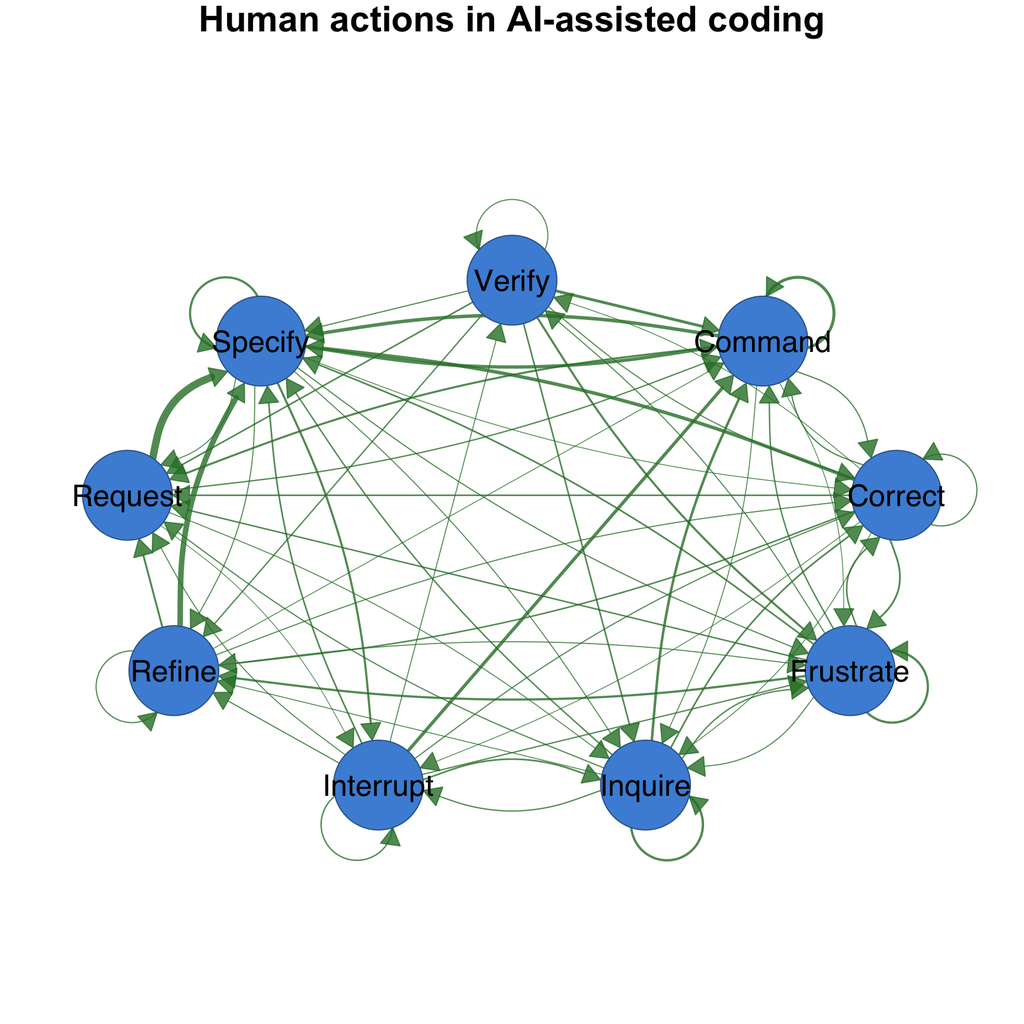

```r
splot(net1, minimum = 0.05,
      title = "Human actions in AI-assisted coding")
```

`plot_simplicial()` puts the extracted rules on that same nine-node layout: each blob is one context and the state it predicts, sources in blue and the target in red. Repeated states get distinct positions, so `Command -> Command -> Correct` covers three visible nodes rather than collapsing onto one. Pass the rules through `pathways =` — this is the same table `as.data.frame()` returns, read as shape rather than as rows.

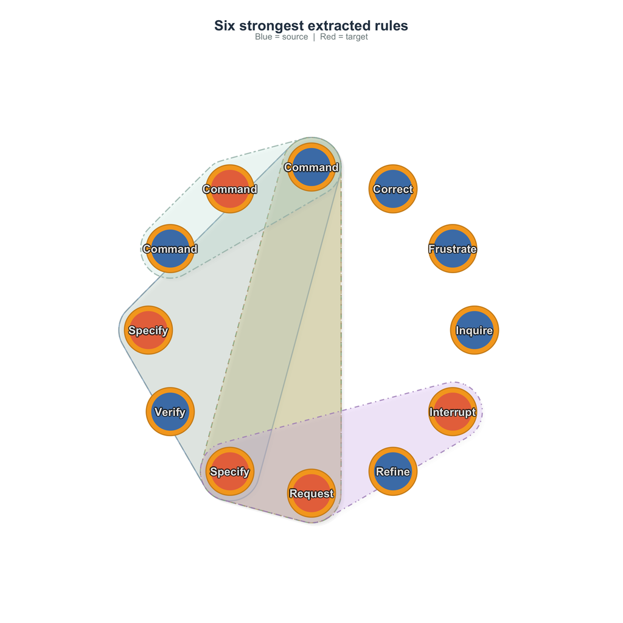

```r
plot_simplicial(net1,
                pathways = as.data.frame(hon, order_min = 2,
                                         sort_by = "count", top = 6),
                max_pathways = 6,
                title = "Six strongest extracted rules")
```

### How much of the network is higher-order?

```r
table(as.data.frame(hon)$from_order)
```

```
  1   2   3
 81 441 297
```

81 first-order rules — the full 9×9 transition structure, since on data this dense every pair occurs. Then 441 second-order and 297 third-order rules were added on top. Roughly nine in ten rules in this network encode memory.

### `min_freq` is the consequential choice

A context is only considered if it occurs at least `min_freq` times. This is the main lever on network size, and it is a statement about how much evidence you require before believing a memory effect.

```r
sizes <- do.call(rbind, lapply(c(5, 20, 50, 100), function(mf) {
  h <- build_hon(human_long, action = "code", actor = "session_id",
                 time = "timestamp", max_order = 3, min_freq = mf)
  data.frame(min_freq = mf, nodes = h$n_nodes, edges = h$n_edges,
             max_order_observed = h$max_order_observed)
}))
sizes
```

```
  min_freq nodes edges max_order_observed
1        5   233   819                  3
2       20    72   223                  3
3       50    23    85                  3
4      100    15    37                  3
```

The network shrinks from 233 nodes to 15 as the evidence bar rises. All four still observe order-3 contexts — the *strongest* memory effects survive even a demanding threshold, which is reassuring. Report the threshold with any result: a claim about a 233-node network and a claim about a 15-node network are different claims.

### Accepted input

`build_hon()` takes sequences in whichever shape you have them.

```r
# a list of character vectors
build_hon(list(c("A", "B", "C", "A", "B"), c("B", "C", "A", "B")),
          max_order = 2, min_freq = 1)
```

```
Higher-Order Network (HON)
  Nodes:        3 (3 first-order states)
  Edges:        3
  Max order:    1 (requested 2)
  Min freq:     1
  Trajectories: 2
```

```r
# a wide data.frame, one sequence per row, trailing NAs stripped
build_hon(data.frame(V1 = c("A", "B"), V2 = c("B", "C"), V3 = c("C", NA)),
          max_order = 2, min_freq = 1)
```

```
Higher-Order Network (HON)
  Nodes:        3 (3 first-order states)
  Edges:        2
  Max order:    1 (requested 2)
  Min freq:     1
  Trajectories: 2
```

It also accepts a fitted `tna` or `netobject` model directly, decoding integer-coded states back to their labels.

### What to do next

- **`markov_order_test()`** — the prior question. Is there memory in these sequences at all? Run it before reporting a higher-order network as evidence of anything.
- **`path_dependence()`** — *which* contexts carry the memory, one row per context, with the divergence that justifies it.
- **`bootstrap_hon()`** — do these rules survive resampling? A rule extracted once is not yet a finding.
- **`hon_centrality()`** — rank the states using the higher-order topology.
- **`build_honem()`** — embed the nodes in a vector space.
- **`build_simplicial(type = "pathway")`** — read the same fitted network as a simplicial complex.

### References

- Xu, J., Wickramarathne, T. L., & Chawla, N. V. (2016). Representing higher-order dependencies in networks. *Science Advances*, 2(5), e1600028.
- Saebi, M., Xu, J., Kaplan, L. M., Ribeiro, B., & Chawla, N. V. (2020). Efficient modeling of higher-order dependencies in networks: from algorithm to application for anomaly detection. *EPJ Data Science*, 9, 15.

## markov_order_test(): does memory exist at all?

### The analytic question

Every higher-order method in this package assumes the sequences have memory. `markov_order_test()` is the question you should ask **before** any of them: does the past predict the future beyond the present state, and if so, how far back?

It fits Markov chains of increasing order, compares them by likelihood-ratio, and — because the asymptotic chi-square reference is unreliable when the transition table is sparse — calibrates the statistic against a **permutation null** built by shuffling within sequences.

```r
library(honets)
seqs <- split(human_long$code, human_long$session_id)
wide <- as.data.frame(do.call(rbind, lapply(
  seqs, function(s) c(s, rep(NA, max(lengths(seqs)) - length(s))))),
  stringsAsFactors = FALSE)
```

### Running it

```r
mk <- markov_order_test(wide, max_order = 3, n_perm = 200, seed = 1)
mk
```

```
Markov Order Test  [within-w permutation, n_perm = 200, alpha = 0.050]
  425 sequences / 10792 observations / 9 states

  Selected order  BIC: 1   AIC: 3   permutation-LRT: 3

 order    loglik      AIC      BIC   df      g2 p_permutation  p_asymptotic
     0 -22031.34 44078.69 44136.98   NA      NA            NA            NA
     1 -20829.39 41818.79 42401.71   64 2375.35   0.004975124  0.000000e+00
     2 -19841.13 41084.25 46192.13  576 1823.84   0.004975124 1.707029e-129
     3 -17163.27 40684.54 63848.51 4721 5191.45   0.004975124  1.324824e-06
 significant
          NA
        TRUE
        TRUE
        TRUE
```

Three criteria, and they **disagree**: BIC selects order 1, AIC and the permutation LRT both select order 3. That disagreement is the result, not a problem to resolve away.

```r
as.data.frame(mk)
```

```
  order    loglik      AIC      BIC   df       g2 p_permutation  p_asymptotic
1     0 -22031.34 44078.69 44136.98   NA       NA            NA            NA
2     1 -20829.39 41818.79 42401.71   64 2375.354   0.004975124  0.000000e+00
3     2 -19841.13 41084.25 46192.13  576 1823.837   0.004975124 1.707029e-129
4     3 -17163.27 40684.54 63848.51 4721 5191.451   0.004975124  1.324824e-06
  significant
1          NA
2        TRUE
3        TRUE
4        TRUE
```

### Reading the disagreement

Look at the `df` column. Going from order 2 to order 3 costs **4,721 extra parameters** on 10,792 observations. AIC charges 2 per parameter; BIC charges `log(n)` ≈ 9.3. On data this size the two criteria are answering different questions:

- **AIC** asks which order predicts best out of sample. It says 3.
- **BIC** asks which order is most likely to be the true generating model. It says 1, because the parameter cost of a third-order chain is enormous relative to the evidence.

Both are right about their own question. For *description* — which is what `build_hon()` does — the AIC/LRT answer is the relevant one, and it is why `max_order = 3` is a sensible ceiling for these data. For a claim that the process **is** third-order Markov, BIC’s scepticism should be reported.

### Seeing the test

`plot()` puts the two panels side by side: the information criteria by order, and the observed statistic against its permutation null. The second panel is the one to read — it shows *how far* outside the null the observed value sits, which the p-value’s floor cannot express.

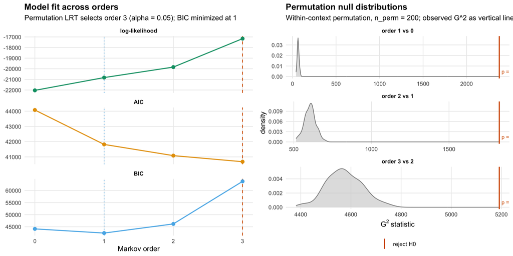

```r
plot(mk)
```

### The permutation p-value has a floor

```r
as.data.frame(mk)
```

```
  order    loglik      AIC      BIC   df       g2 p_permutation  p_asymptotic
1     0 -22031.34 44078.69 44136.98   NA       NA            NA            NA
2     1 -20829.39 41818.79 42401.71   64 2375.354   0.004975124  0.000000e+00
3     2 -19841.13 41084.25 46192.13  576 1823.837   0.004975124 1.707029e-129
4     3 -17163.27 40684.54 63848.51 4721 5191.451   0.004975124  1.324824e-06
  significant
1          NA
2        TRUE
3        TRUE
4        TRUE
```

Every permutation p-value is 0.004975 — that is `1 / (200 + 1)`, the **smallest value 200 permutations can produce**. It does not mean the three orders are equally significant; it means all three exceeded every one of their 200 null replicates. Raise `n_perm` if you need to resolve below that floor.

Note also how far the asymptotic p-values sit from it: 1.7e-129 at order 2. That is the sparsity problem the permutation null exists to avoid — with 576 degrees of freedom over nine states, the chi-square approximation is not trustworthy, and the permutation value is the one to report.

### The null distribution itself

`what = "null"` returns the replicates, so the calibration can be inspected rather than trusted.

```r
nulls <- as.data.frame(mk, what = "null")
as.data.frame(mk, what = "null", top = 4)
```

```
  order replicate       g2
1     1         1 67.28721
2     1         2 83.43090
3     1         3 67.25021
4     1         4 72.83490
```

```r
aggregate(g2 ~ order, data = nulls,
          FUN = function(x) round(c(mean = mean(x), max = max(x)), 1))
```

```
  order g2.mean g2.max
1     1    65.1   98.7
2     2   604.4  706.7
3     3  4574.3 4766.5
```

Compare each order’s observed `g2` in the table above against the maximum its null ever reached. The observed statistics are far outside — which is what “p at the floor” means, made concrete.

### Cost and reproducibility

Permutations dominate the runtime. `parallel = TRUE` uses `parallel::mclapply` (skipped on Windows), and all randomness is drawn serially before any parallel work, so **a parallel run reproduces the serial result exactly under the same seed**.

```r
markov_order_test(wide, max_order = 3, n_perm = 2000,
                  parallel = TRUE, n_cores = 4, seed = 1)
```

Always pass `seed`. A permutation test reported without one is not reproducible.

### What to do next

- **`build_hon()`** — if there is memory, build the network that represents it. Use the selected order as the `max_order` ceiling.
- **`path_dependence()`** — this test is global. That one localises the memory to individual contexts.
- **`build_mogen()`** — the same model-selection question under a multi-order generative model, which mixes orders rather than choosing one.

### References

- Anderson, T. W., & Goodman, L. A. (1957). Statistical inference about Markov chains. *The Annals of Mathematical Statistics*, 28(1), 89-110.
- Good, P. (2005). *Permutation, Parametric and Bootstrap Tests of Hypotheses*. Springer.

## path_dependence(): which contexts carry the memory

### The analytic question

`markov_order_test()` answers a global question: *is there memory in these sequences?* It returns one verdict for the whole corpus.

`path_dependence()` localises it. For every order-k context it asks: **how different is what happens next, once you know the context, from what happens next if you only know the current state?** The answer is a Kullback-Leibler divergence in bits, one row per context, so memory stops being a property of the dataset and becomes a property of specific situations.

```r
library(honets)
seqs <- split(human_long$code, human_long$session_id)
wide <- as.data.frame(do.call(rbind, lapply(
  seqs, function(s) c(s, rep(NA, max(lengths(seqs)) - length(s))))),
  stringsAsFactors = FALSE)
```

### Running it

```r
pd <- path_dependence(wide, order = 2)
pd
```

```
Path Dependence (order 2 vs order 1, bits)

Contexts: 81 (min_count = 5).  Modal-prediction flips: 35.
Chain-level KL_weighted      = 0.143 bits
Chain-level H_drop_weighted  = 0.109 bits

Top 10 contexts by KL:
                context   n H_order1 H_orderk H_drop    KL    top_o1    top_ok
 Interrupt -> Interrupt  53    3.021    2.034  0.987 1.065   Command Interrupt
    Refine -> Interrupt  20    3.021    2.646  0.375 0.562   Command   Correct
    Verify -> Interrupt  19    3.021    2.525  0.496 0.513   Command   Command
     Request -> Correct  20    2.960    2.509  0.451 0.478   Specify   Request
      Verify -> Specify  40    2.921    2.454  0.467 0.454   Command   Specify
   Frustrate -> Specify 112    2.921    2.767  0.154 0.410   Command   Specify
     Inquire -> Specify  84    2.921    2.601  0.320 0.401   Command   Specify
       Refine -> Verify  13    3.025    2.719  0.306 0.384   Command   Command
 Frustrate -> Interrupt  42    3.021    2.747  0.275 0.366   Command   Inquire
    Verify -> Frustrate  79    3.071    2.845  0.226 0.307 Frustrate    Verify
 flips
  TRUE
  TRUE
 FALSE
  TRUE
  TRUE
  TRUE
  TRUE
 FALSE
  TRUE
  TRUE
```

Two chain-level numbers summarise the corpus: knowing the previous action as well as the current one buys **0.143 bits** on average, and cuts the uncertainty about the next action by **0.109 bits**. Those are modest averages hiding a very uneven distribution.

### The uneven part

```r
as.data.frame(pd, sort_by = "KL", top = 8)
```

```
                 context   n H_order1 H_orderk    H_drop        KL  top_o1
1 Interrupt -> Interrupt  53 3.021432 2.034047 0.9873847 1.0648142 Command
2    Refine -> Interrupt  20 3.021432 2.646439 0.3749922 0.5618498 Command
3    Verify -> Interrupt  19 3.021432 2.525346 0.4960859 0.5126280 Command
4     Request -> Correct  20 2.959941 2.508695 0.4512464 0.4781715 Specify
5      Verify -> Specify  40 2.921052 2.454175 0.4668774 0.4544747 Command
6   Frustrate -> Specify 112 2.921052 2.766610 0.1544421 0.4095297 Command
7     Inquire -> Specify  84 2.921052 2.601462 0.3195901 0.4012625 Command
8       Refine -> Verify  13 3.025235 2.719295 0.3059406 0.3841578 Command
     top_ok flips
1 Interrupt  TRUE
2   Correct  TRUE
3   Command FALSE
4   Request  TRUE
5   Specify  TRUE
6   Specify  TRUE
7   Specify  TRUE
8   Command FALSE
```

`Interrupt -> Interrupt` diverges by **1.065 bits** — seven times the corpus average. Its entropy drops from 3.02 to 2.03 bits, meaning that once you know an interruption followed an interruption, you have roughly halved your uncertainty about what comes next.

### Seeing which contexts carry it

`plot()` is a dot plot of per-context divergence, sized by how often the context occurs. The long right tail is the point: memory is concentrated in a handful of situations, not spread evenly.

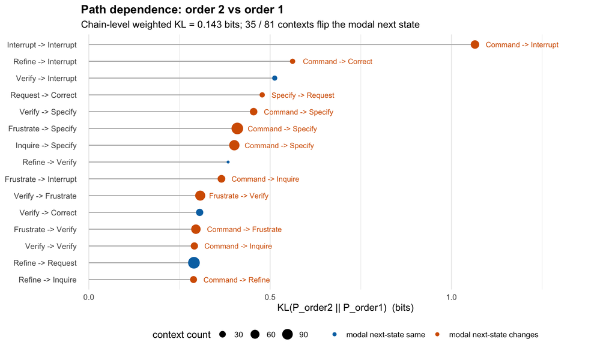

```r
plot(pd)
```

### `flips` is the column that matters most

`flips` is `TRUE` when the context changes the *modal* prediction — the single most likely next action differs from what the first-order model would have said.

```r
pd_all <- as.data.frame(pd)
table(flips = pd_all$flips)
```

```
flips
FALSE  TRUE
   46    35
```

35 of the 81 contexts flip the prediction. That is the practical statement of what memory buys here: in **43% of situations, a first-order model would name the wrong most-likely next action**.

```r
as.data.frame(pd, sort_by = "KL", top = 5)
```

```
                 context  n H_order1 H_orderk    H_drop        KL  top_o1
1 Interrupt -> Interrupt 53 3.021432 2.034047 0.9873847 1.0648142 Command
2    Refine -> Interrupt 20 3.021432 2.646439 0.3749922 0.5618498 Command
3    Verify -> Interrupt 19 3.021432 2.525346 0.4960859 0.5126280 Command
4     Request -> Correct 20 2.959941 2.508695 0.4512464 0.4781715 Specify
5      Verify -> Specify 40 2.921052 2.454175 0.4668774 0.4544747 Command
     top_ok flips
1 Interrupt  TRUE
2   Correct  TRUE
3   Command FALSE
4   Request  TRUE
5   Specify  TRUE
```

Read `Interrupt -> Interrupt`: a first-order model predicts `Command` next (because `Command` is what usually follows `Interrupt`), but conditioned on the repeat, the modal continuation is another `Interrupt`. Interruptions cluster, and only the higher-order view sees it.

### KL and entropy drop are different questions

Both columns are reported because they answer different things.

```r
as.data.frame(pd, sort_by = "KL", top = 6)
```

```
                 context   n H_order1 H_orderk    H_drop        KL  top_o1
1 Interrupt -> Interrupt  53 3.021432 2.034047 0.9873847 1.0648142 Command
2    Refine -> Interrupt  20 3.021432 2.646439 0.3749922 0.5618498 Command
3    Verify -> Interrupt  19 3.021432 2.525346 0.4960859 0.5126280 Command
4     Request -> Correct  20 2.959941 2.508695 0.4512464 0.4781715 Specify
5      Verify -> Specify  40 2.921052 2.454175 0.4668774 0.4544747 Command
6   Frustrate -> Specify 112 2.921052 2.766610 0.1544421 0.4095297 Command
     top_ok flips
1 Interrupt  TRUE
2   Correct  TRUE
3   Command FALSE
4   Request  TRUE
5   Specify  TRUE
6   Specify  TRUE
```

`H_drop` is how much *uncertainty* the context removes. `KL` is how far the context’s distribution has *moved* from the first-order one. A context can move a long way without becoming more predictable — `Frustrate -> Specify` has a high KL (0.410) on a small entropy drop (0.154), meaning it reshuffles which continuations are likely without concentrating them.

### `min_count` guards against noise

Divergence is easy to manufacture from a handful of observations. Contexts below `min_count` are dropped.

```r
do.call(rbind, lapply(c(5, 20, 50), function(mc) {
  p <- path_dependence(wide, order = 2, min_count = mc)
  d <- as.data.frame(p)
  data.frame(min_count = mc, contexts = nrow(d),
             mean_KL = round(mean(d$KL), 3),
             flips = sum(d$flips))
}))
```

```
  min_count contexts mean_KL flips
1         5       81   0.186    35
2        20       79   0.179    35
3        50       61   0.157    27
```

The mean KL *falls* as the threshold rises — from 0.186 to 0.157 — which is evidence that some of the apparent memory at `min_count = 5` is small-sample noise. The effect is mild here: only two contexts fall below 20 occurrences, and the flip count holds at 35 until the threshold reaches 50, where 20 sparse contexts drop out and 27 flips remain. That stability is itself reassuring. Report the threshold regardless.

### Higher orders

```r
pd3 <- path_dependence(wide, order = 3, min_count = 20)
pd3
```

```
Path Dependence (order 3 vs order 1, bits)

Contexts: 137 (min_count = 20).  Modal-prediction flips: 71.
Chain-level KL_weighted      = 0.301 bits
Chain-level H_drop_weighted  = 0.270 bits

Top 10 contexts by KL:
                             context   n H_order1 H_orderk H_drop    KL
 Interrupt -> Interrupt -> Interrupt  24    3.021    0.900  2.121 2.338
    Frustrate -> Verify -> Frustrate  27    3.071    2.247  0.824 0.958
     Correct -> Frustrate -> Specify  20    2.921    2.284  0.637 0.927
         Refine -> Refine -> Specify  29    2.921    2.528  0.394 0.904
       Inquire -> Correct -> Specify  22    2.921    2.720  0.201 0.894
   Frustrate -> Frustrate -> Specify  24    2.921    1.984  0.937 0.842
       Verify -> Frustrate -> Verify  22    3.025    2.106  0.919 0.795
       Inquire -> Inquire -> Correct  23    2.960    2.305  0.655 0.772
       Command -> Request -> Specify 223    2.921    2.108  0.813 0.771
     Frustrate -> Request -> Specify  40    2.921    2.641  0.280 0.676
    top_o1    top_ok flips
   Command Interrupt  TRUE
 Frustrate    Verify  TRUE
   Command   Specify  TRUE
   Command    Refine  TRUE
   Command   Inquire  TRUE
   Command   Specify  TRUE
   Command Frustrate  TRUE
   Specify   Specify FALSE
   Command Interrupt  TRUE
   Command Frustrate  TRUE
```

### What to do next

- **`markov_order_test()`** — the global test this verb decomposes. Run it first.
- **`build_hon()`** — the contexts with high KL are exactly the ones BuildHON+ promotes to higher-order nodes.
- **`bootstrap_hon()`** — before reporting a specific context as a finding, check that it survives resampling.

### References

- Cover, T. M., & Thomas, J. A. (2006). *Elements of Information Theory* (2nd ed.). Wiley.
- Xu, J., Wickramarathne, T. L., & Chawla, N. V. (2016). Representing higher-order dependencies in networks. *Science Advances*, 2(5), e1600028.

## build_mogen(): choosing an order instead of assuming one

### The analytic question

`build_hon()` decides *per context* whether memory is warranted. `build_mogen()` asks the question at the level of the whole model: fit Markov chains of every order from 0 up to `max_order`, score each one, and report which order the data actually support.

The multi-order model of Scholtes (2017) treats the layers as a *nested family* — each order’s likelihood is computed on the paths it can explain, with the degrees of freedom that order costs — so the comparison is a like-for-like model selection rather than a race between separately-fitted models.

```r
library(honets)
seqs <- split(human_long$code, human_long$session_id)
```

```r
library(cograph)
```

### Fitting

```r
mo <- build_mogen(seqs, max_order = 4)
mo
```

```
Multi-Order Generative Model (MOGen)
  Optimal order:  4 (by aic)
  Orders tested:  0 to 4
  States:         9
  Paths:          425 (10792 observations)
  AIC:            44078.7 | 41818.8 | 41084.3 | 40684.5 | 35293.7*
  BIC:            44137.0 | 42401.7* | 46192.1 | 63848.5 | 81060.6
  (* = minimum;  AIC favors order 4, BIC favors order 1)
```

The print method flags the minimum of each criterion, and here they **disagree**: AIC selects order 4, BIC selects order 1. The asterisks make the disagreement visible rather than hiding it behind a single “optimal order”.

### The selection table

```r
as.data.frame(mo)
```

```
  order log_likelihood      aic      bic  dof layer_dof optimal
1     0      -22031.34 44078.69 44136.98    8         8   FALSE
2     1      -20829.39 41818.79 42401.71   80        72   FALSE
3     2      -19841.13 41084.25 46192.13  701       621   FALSE
4     3      -17163.27 40684.54 63848.51 3179      2478   FALSE
5     4      -11365.83 35293.66 81060.55 6281      3102    TRUE
```

The `dof` column explains everything. Going from order 3 to order 4 adds 3,102 parameters (`layer_dof`) on 10,792 observations. The log-likelihood improves substantially — from −17,163 to −11,366 — so AIC, which charges 2 per parameter, is delighted. BIC charges `log(10792)` ≈ 9.3 per parameter and is appalled: its score rises from 42,402 at order 1 to 81,061 at order 4.

`optimal` marks the order selected under the criterion you asked for (`criterion = "aic"` by default).

### Seeing the selection

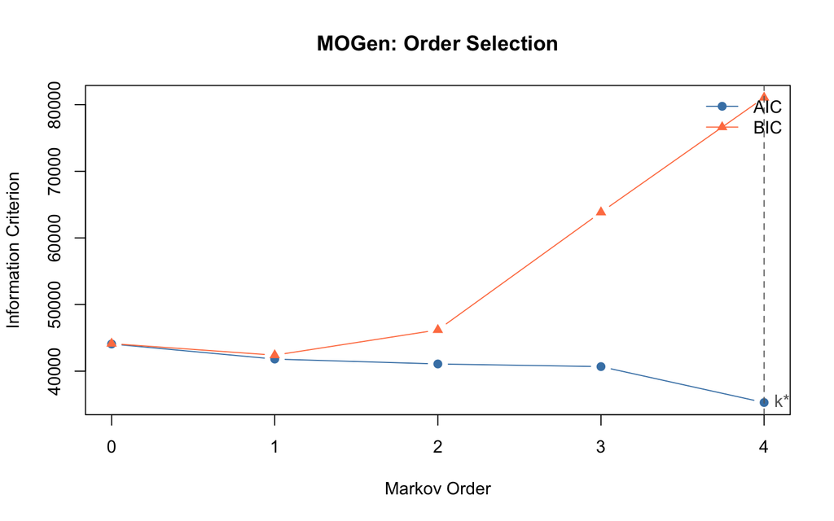

```r
plot(mo)
```

### Which criterion should you use?

It depends on what the model is for.

- **Describing the corpus** — AIC. You want the order that best captures the structure actually present, and over-parameterisation is a cost you are willing to pay for fidelity.
- **Claiming the process is order-k** — BIC. It is consistent for model identification, and its verdict of order 1 is a real warning that a fourth-order chain is not *identifiable* from 425 sessions.
- **Testing whether order k improves on k−1** — neither; use `markov_order_test()`, which calibrates the likelihood-ratio statistic against a permutation null rather than an information criterion.

```r
mo_bic <- build_mogen(seqs, max_order = 4, criterion = "bic")
mo_bic$optimal_order
```

```
[1] 1
```

Switching the criterion changes the selected order, and it should be reported alongside the result.

### The fitted transitions

`mogen_transitions()` is the tidy accessor for the fitted layer.

```r
mogen_transitions(mo, top = 5)
```

```
                                                   path count probability
1 Specify -> Command -> Request -> Specify -> Interrupt   127      0.7175
2 Specify -> Command -> Specify -> Interrupt -> Command    48      0.3902
3 Command -> Request -> Specify -> Interrupt -> Command    37      0.2721
4   Command -> Command -> Command -> Command -> Command    27      0.3803
5  Command -> Request -> Specify -> Interrupt -> Verify    27      0.1985
                                        from        to
1   Specify -> Command -> Request -> Specify Interrupt
2 Specify -> Command -> Specify -> Interrupt   Command
3 Command -> Request -> Specify -> Interrupt   Command
4   Command -> Command -> Command -> Command   Command
5 Command -> Request -> Specify -> Interrupt    Verify
```

At order 4, a “state” is a four-step history. The heaviest is `Specify -> Command -> Request -> Specify` continuing to `Interrupt`, 127 times at probability 0.72 — a highly deterministic recurring routine, and the kind of structure that only a high-order layer can express.

The same table is reachable through the standard accessor, and `order =` selects a different layer:

```r
as.data.frame(mo, what = "transitions", order = 2, top = 4)
```

```
                             path count probability               from
1   Specify -> Command -> Specify   284      0.3901 Specify -> Command
2   Command -> Request -> Specify   231      0.7649 Command -> Request
3   Specify -> Command -> Request   199      0.2734 Specify -> Command
4 Request -> Specify -> Interrupt   189      0.3259 Request -> Specify
         to
1   Specify
2   Specify
3   Request
4 Interrupt
```

### The fitted layer as shape

`plot_simplicial()` takes a `mogen_transitions()` table directly through `pathways =`, so the fitted second-order layer can be read as shape over the network rather than as 702 rows. The network it draws on is the **first-order** one — nine states. Because `mogen_transitions()` returns rows already sorted by count, `top = N` picks the N heaviest.

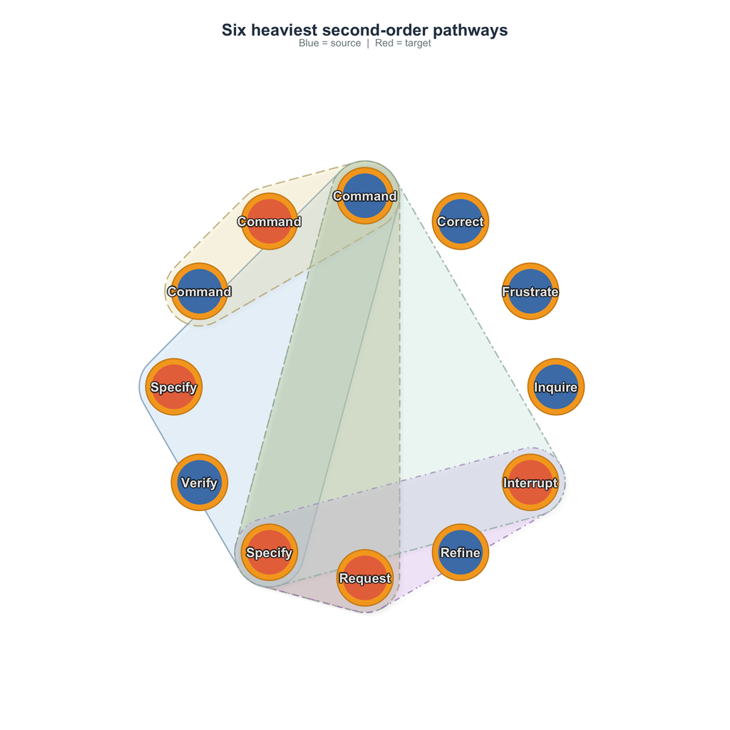

```r
net1 <- build_hon(seqs, max_order = 1)
plot_simplicial(net1, pathways = mogen_transitions(mo, order = 2, top = 6),
                max_pathways = 6,
                title = "Six heaviest second-order pathways")
```

A single pathway, isolated:

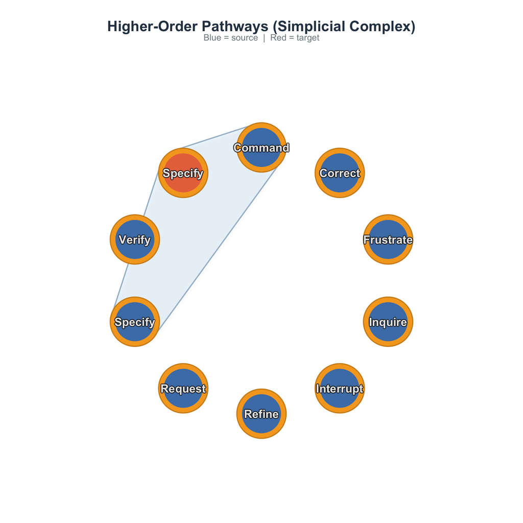

```r
plot_simplicial(net1, pathways = mogen_transitions(mo, order = 2, top = 1),
                max_pathways = 1)
```

### Path counts without fitting a model

`path_counts()` is the descriptive counterpart: how often does each k-step path occur, with no model behind it.

```r
path_counts(seqs, k = 3, top = 6)
```

```
                             path count proportion
1   Specify -> Command -> Specify   284     0.0286
2   Command -> Request -> Specify   231     0.0232
3   Specify -> Command -> Request   199     0.0200
4 Request -> Specify -> Interrupt   189     0.0190
5   Command -> Command -> Command   177     0.0178
6 Command -> Specify -> Interrupt   149     0.0150
```

Useful as a sanity check before fitting, and for reporting the raw evidence under a modelled claim.

### A caution on `max_order`

Raising `max_order` is not free. The parameter count grows roughly as `|S|^(k+1)`, and past a certain point the higher layers are fitting individual sequences.

```r
do.call(rbind, lapply(2:4, function(k) {
  m <- build_mogen(seqs, max_order = k)
  d <- as.data.frame(m)
  data.frame(max_order = k, selected_aic = m$optimal_order,
             top_layer_dof = max(d$layer_dof))
}))
```

```
  max_order selected_aic top_layer_dof
1         2            2           621
2         3            3          2478
3         4            4          3102
```

If AIC keeps selecting whatever ceiling you set, that is a sign the ceiling is doing the choosing, not the data. Check BIC and the permutation test before believing it.

### What to do next

- **`markov_order_test()`** — the permutation-based version of this question, which does not rely on an information criterion.
- **`build_hon()`** — per-context order selection instead of one order for the whole model.
- **`build_hypa()`** — which specific paths occur more or less often than a null model expects.
- **`pathways()`** — hand the fitted model’s paths to the simplicial and hypergraph families.

### References

- Scholtes, I. (2017). When is a network a network? Multi-order graphical model selection in pathways and temporal networks. *KDD 2017*, 1037-1046.
- Gote, C., & Scholtes, I. (2023). Predicting sequences of traversed nodes in graphs using network models with multiple higher orders. *Data Mining and Knowledge Discovery*.

## build_hypa(): which paths are anomalous

### The analytic question

A frequent path is not necessarily a surprising one. `Specify -> Command` is common largely because `Specify` and `Command` are both common — the count tells you about the states, not about the pairing.

`build_hypa()` (LaRock et al. 2020) separates the two. It asks: given how often each state is entered and left, **how often would this path occur by chance?** The null is a Wallenius non-central hypergeometric model, which holds the marginal in- and out-degrees fixed and lets the paths fall where they may. A path that beats its own expectation is carrying information the degree structure does not explain.

```r
library(honets)
seqs <- split(human_long$code, human_long$session_id)
```

```r
library(cograph)
```

### Running it

```r
hp <- build_hypa(seqs, order = 2)
hp
```

```
HYPA: Path Anomaly Detection
  Order(s):     2
  Edges:        702
  Anomalous:    185 (alpha=0.05, p_adjust=BH)
    Over-repr:  139
    Under-repr: 46
```

Of the 702 second-order paths, 139 occur significantly more often than expected and 46 significantly less, after Benjamini-Hochberg correction.

### Over-represented paths

```r
as.data.frame(hp, what = "over", sort_by = "ratio", top = 6)
```

```
                                 path                   from        to observed
1 Interrupt -> Interrupt -> Interrupt Interrupt -> Interrupt Interrupt       29
2    Frustrate -> Verify -> Frustrate    Frustrate -> Verify Frustrate       27
3      Refine -> Interrupt -> Correct    Refine -> Interrupt   Correct        6
4      Verify -> Interrupt -> Request    Verify -> Interrupt   Request        5
5         Verify -> Verify -> Inquire       Verify -> Verify   Inquire       10
6         Refine -> Inquire -> Refine      Refine -> Inquire    Refine        8
   expected     ratio   p_value   p_under       p_over anomaly p_adjusted_under
1 2.8056829 10.336165 1.0000000 1.0000000 6.611027e-20    over                1
2 3.7418392  7.215703 1.0000000 1.0000000 6.929436e-15    over                1
3 0.8358539  7.178288 0.9999731 0.9999731 2.302764e-04    over                1
4 0.7146551  6.996382 0.9999006 0.9999006 8.541929e-04    over                1
5 1.4947854  6.689924 0.9999995 0.9999995 3.903186e-06    over                1
6 1.2551739  6.373619 0.9999932 0.9999932 4.983103e-05    over                1
  p_adjusted_over order
1    4.640941e-17     2
2    1.216116e-12     2
3    2.993593e-03     2
4    8.103289e-03     2
5    1.522243e-04     2
6    1.025907e-03     2
```

The top row occurs **10.3 times** more often than the degree structure predicts. That is the signature of a routine — a sequence the sessions actually follow, rather than one the marginals happen to produce.

### Under-represented paths are the more interesting half

```r
as.data.frame(hp, what = "under", sort_by = "ratio", top = 4)
```

```
                             path                 from        to observed
1   Command -> Specify -> Command   Command -> Specify   Command      110
2 Interrupt -> Command -> Specify Interrupt -> Command   Specify       49
3  Refine -> Specify -> Frustrate    Refine -> Specify Frustrate       35
4   Specify -> Specify -> Command   Specify -> Specify   Command       77
   expected     ratio      p_value      p_under    p_over anomaly
1 147.27328 0.7469108 7.359103e-04 7.359103e-04 0.9994650   under
2  71.35267 0.6867298 3.181869e-03 3.181869e-03 0.9978997   under
3  54.39180 0.6434794 3.263730e-03 3.263730e-03 0.9979921   under
4 126.46887 0.6088455 1.267036e-06 1.267036e-06 0.9999992   under
  p_adjusted_under p_adjusted_over order
1     1.148020e-02               1     2
2     4.467344e-02               1     2
3     4.492428e-02               1     2
4     3.294294e-05               1     2
```

`Specify -> Specify -> Command` is observed 77 times against an expectation of 126 — a ratio of 0.61. It is a *frequent* path (77 occurrences is not rare) that is nonetheless **avoided**. A count-based analysis would list it among the common transitions and miss entirely that it happens far less than it should.

Absences are hard to see and easy to under-report. This is the column that finds them.

### Seeing the anomalies

`plot_simplicial()` dispatches on `net_hypa` and ranks pathways by ratio, so the most extreme deviations come first. `dismantled = TRUE` gives each path its own panel, which is what makes overlapping routines readable.

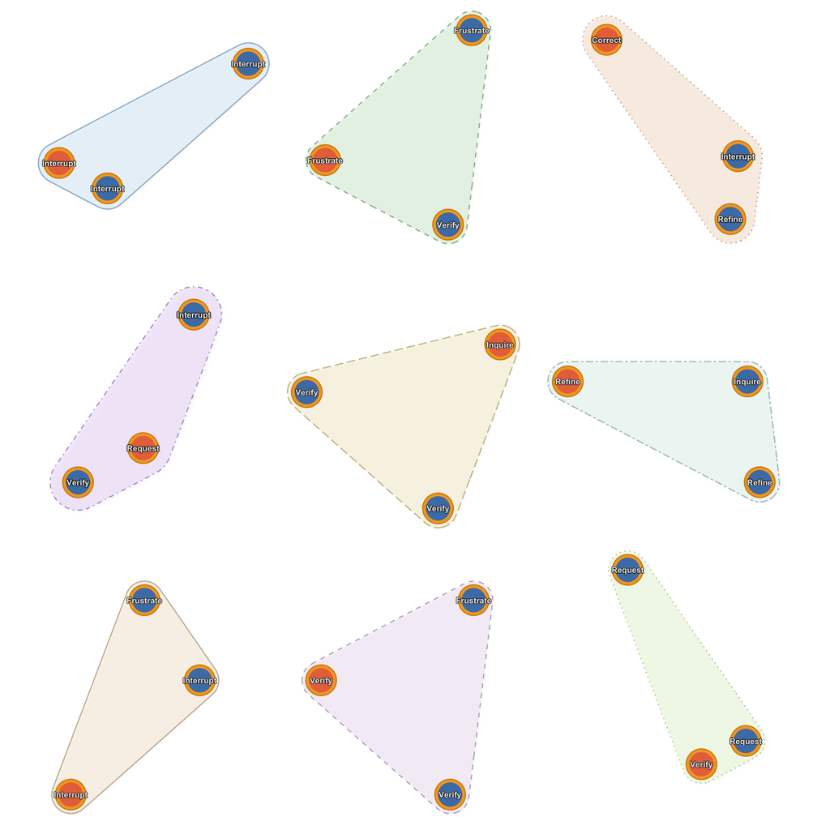

```r
plot_simplicial(hp, anomaly = "over", max_pathways = 9,
                dismantled = TRUE, ncol = 3)
```

The under-represented half — the paths the sessions *avoid* — is the harder one to see in a table and the easier one to see here:

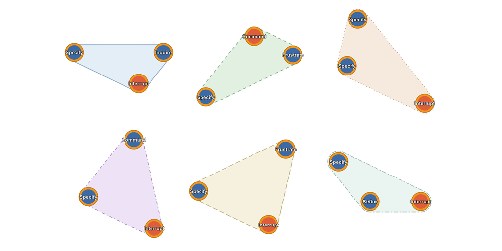

```r
plot_simplicial(hp, anomaly = "under", max_pathways = 6,
                dismantled = TRUE, ncol = 3)
```

### Ratio and p-value rank differently

```r
as.data.frame(hp, what = "over", sort_by = "ratio", top = 3)
```

```
                                 path                   from        to observed
1 Interrupt -> Interrupt -> Interrupt Interrupt -> Interrupt Interrupt       29
2    Frustrate -> Verify -> Frustrate    Frustrate -> Verify Frustrate       27
3      Refine -> Interrupt -> Correct    Refine -> Interrupt   Correct        6
   expected     ratio   p_value   p_under       p_over anomaly p_adjusted_under
1 2.8056829 10.336165 1.0000000 1.0000000 6.611027e-20    over                1
2 3.7418392  7.215703 1.0000000 1.0000000 6.929436e-15    over                1
3 0.8358539  7.178288 0.9999731 0.9999731 2.302764e-04    over                1
  p_adjusted_over order
1    4.640941e-17     2
2    1.216116e-12     2
3    2.993593e-03     2
```

```r
as.data.frame(hp, what = "over", sort_by = "observed", top = 3)
```

```
                           path               from      to observed expected
1 Command -> Request -> Specify Command -> Request Specify      231 130.4211
2 Specify -> Command -> Request Specify -> Command Request      199 155.1679
3 Command -> Command -> Command Command -> Command Command      177 146.4249
     ratio   p_value   p_under       p_over anomaly p_adjusted_under
1 1.771186 1.0000000 1.0000000 7.403248e-16    over                1
2 1.282482 0.9997198 0.9997198 3.683290e-04    over                1
3 1.208811 0.9941014 0.9941014 7.344894e-03    over                1
  p_adjusted_over order
1    1.732360e-13     2
2    4.287128e-03     2
3    4.049601e-02     2
```

The most *surprising* paths and the most *frequent* surprising paths are different sets. Sort by `ratio` to find structure; sort by `observed` to find structure that carries weight. Report which you used.

### Multiplicity is handled, and directional

702 paths are tested, so raw p-values would be meaningless. `build_hypa()` applies Benjamini-Hochberg by default and reports **separate adjusted values for each direction** — `p_adjusted_over` and `p_adjusted_under` — because a path cannot be simultaneously over- and under-represented and pooling them would be wrong.

```r
as.data.frame(hp, sort_by = "p", top = 4)
```

```
                             path               from        to observed
1 Specify -> Specify -> Interrupt Specify -> Specify Interrupt       34
2   Specify -> Command -> Command Specify -> Command   Command       98
3  Refine -> Specify -> Interrupt  Refine -> Specify Interrupt       31
4   Command -> Specify -> Specify Command -> Specify   Specify       77
  expected     ratio      p_value      p_under p_over anomaly p_adjusted_under
1 149.6387 0.2272139 1.972657e-30 1.972657e-30      1   under     1.384805e-27
2 233.7660 0.4192226 2.830720e-24 2.830720e-24      1   under     9.935826e-22
3 111.4193 0.2782282 1.378800e-19 1.378800e-19      1   under     3.226391e-17
4 179.8758 0.4280733 2.219127e-18 2.219127e-18      1   under     3.894568e-16
  p_adjusted_over order
1               1     2
2               1     2
3               1     2
4               1     2
```

`p_value` is the two-sided value; the directional adjusted columns are the ones to act on. `alpha` and `p_adjust` control the threshold and method:

```r
hp_strict <- build_hypa(seqs, order = 2, alpha = 0.001, p_adjust = "bonferroni")
hp_strict
```

```
HYPA: Path Anomaly Detection
  Order(s):     2
  Edges:        702
  Anomalous:    42 (alpha=0.00, p_adjust=bonferroni)
    Over-repr:  15
    Under-repr: 27
```

Under Bonferroni at α = 0.001 the anomaly count falls sharply — the paths that survive are the ones worth naming in a result.

### `min_count` and order

```r
do.call(rbind, lapply(c(5, 20), function(mc) {
  h <- build_hypa(seqs, order = 2, min_count = mc)
  data.frame(min_count = mc, scored = nrow(as.data.frame(h)),
             over = h$n_over, under = h$n_under)
}))
```

```
  min_count scored over under
1         5    702  139    46
2        20    702   53    35
```

Higher orders test longer paths, and the table grows quickly — check that each path still has enough observations to support a claim.

### What to do next

- **`build_hon()`** — HYPA scores paths against a null; BuildHON+ decides which contexts deserve their own node. They answer different questions about the same sequences.
- **`bootstrap_hon()`** — resampling-based stability for extracted rules.
- **`path_dependence()`** — per-context divergence rather than per-path anomaly.
- **`pathways()`** — pass the scored paths on to the simplicial family.

### References

- LaRock, T., Nanumyan, V., Scholtes, I., Casiraghi, G., Eliassi-Rad, T., & Schweitzer, F. (2020). HYPA: Efficient detection of path anomalies in time series over networks. *Proceedings of the 2020 SIAM International Conference on Data Mining*, 460-468.
- Benjamini, Y., & Hochberg, Y. (1995). Controlling the false discovery rate. *Journal of the Royal Statistical Society B*, 57(1), 289-300.

## build_honem(): embedding a higher-order network

### The analytic question

Network embeddings put nodes in a vector space so that structurally similar nodes end up near each other, making the network usable by anything that takes numeric features — clustering, regression, a downstream classifier.

Applied to a *first-order* network, an embedding can only encode who follows whom. HONEM (Saebi, Ciampaglia, Kaplan & Chawla 2020) embeds the **higher-order** network instead, so the vector for `Specify -> Command` reflects that context’s own continuation behaviour, not just `Command`’s.

The method builds higher-order neighbourhood matrices out to `max_power` steps, sums them into a single deviation matrix, and takes a truncated SVD.

```r
library(honets)
seqs <- split(human_long$code, human_long$session_id)
```

```r
library(cograph)
```

### Embedding

`build_honem()` consumes a fitted network, not raw sequences — build the higher-order network first and embed that.

```r
hon <- build_hon(seqs, max_order = 3, min_freq = 5)
em <- build_honem(hon, dim = 8)
em
```

```
HONEM: Higher-Order Network Embedding
  Nodes:      233
  Dimensions: 8
  Max power:  10
  Variance explained: 26.9%
```

233 nodes in 8 dimensions.

### Reading the coordinates

```r
as.data.frame(em, top = 6)
```

```
                             node       dim1         dim2         dim3
1                         Command 0.10835389 -0.154398248  0.051715108
2              Command -> Command 0.11456024 -0.193731474  0.070149078
3   Command -> Command -> Correct 0.02664611 -0.015416814  0.002878285
4 Command -> Command -> Frustrate 0.01972895 -0.006046598  0.003764183
5   Command -> Command -> Inquire 0.02891076 -0.062085853  0.023099962
6    Command -> Command -> Refine 0.14860198  0.022368050 -0.045598254
         dim4         dim5        dim6         dim7         dim8
1  0.02510722 -0.028266138  0.02764478 -0.031559640  0.009033542
2  0.00781994  0.003456093  0.01830600 -0.039714746  0.012523183
3 -0.01340167 -0.040384284 -0.02864752  0.007903811 -0.021335451
4 -0.01795680 -0.040783509 -0.17152152 -0.081260154  0.041315185
5 -0.09540003  0.128580191 -0.04820936  0.067604069 -0.012022753
6  0.14810405  0.035489749  0.05454319  0.010859133  0.019249940
```

One row per higher-order node. Note what the rows are: `Command` is a first-order node, `Command -> Command` a second-order context, and `Command -> Command -> Correct` a third-order one. **All three are embedded in the same space**, which is what makes the representation useful — a context and the state it ends in can be compared directly.

### How many dimensions do you need?

```r
as.data.frame(em, what = "variance")
```

```
  dim singular_value proportion
1   1       1.929934 0.24268255
2   2       1.566702 0.15992874
3   3       1.479560 0.14263267
4   4       1.212437 0.09577948
5   5       1.205881 0.09474638
6   6       1.178771 0.09053424
7   7       1.168708 0.08899499
8   8       1.140164 0.08470095
```

The first dimension carries 24.3% of the squared singular value, the second 16.0%, and the tail flattens quickly — dimensions 4 through 8 each hold 8-10%. There is no sharp elbow, which is honest information: this network has no small set of dominant structural axes, and an 8-dimensional embedding is retaining genuinely distributed structure rather than noise.

```r
em20 <- build_honem(hon, dim = 20)
as.data.frame(em20, what = "variance", top = 6)
```

```
  dim singular_value proportion
1   1       1.929934 0.13227595
2   2       1.566702 0.08717036
3   3       1.479560 0.07774301
4   4       1.212437 0.05220533
5   5       1.205881 0.05164223
6   6       1.178771 0.04934637
```

```r
cumulative <- cumsum(as.data.frame(em20, what = "variance")$proportion)
data.frame(dims = c(2, 5, 10, 20), cumulative = round(cumulative[c(2, 5, 10, 20)], 3))
```

```
  dims cumulative
1    2      0.219
2    5      0.401
3   10      0.632
4   20      1.000
```

**`proportion` is relative to the dimensions retained, not to the full spectrum** — it sums to 1 by construction, so the same axis has a different share depending on `dim`. At `dim = 20` the first two axes hold 21.9% and the first ten 63.2%; the 24.3% reported for `dim1` above is its share of an 8-dimensional retention.

Compare like with like when choosing `dim`, and report the value you used.

### `max_power` sets how far the neighbourhood reaches

```r
do.call(rbind, lapply(c(2, 5, 10), function(mp) {
  e <- build_honem(hon, dim = 4, max_power = mp)
  v <- as.data.frame(e, what = "variance")
  data.frame(max_power = mp, dim1_share = round(v$proportion[1], 3),
             top4_share = round(sum(v$proportion), 3))
}))
```

```
  max_power dim1_share top4_share
1         2      0.365          1
2         5      0.378          1
3        10      0.379          1
```

Larger `max_power` accumulates longer-range neighbourhoods. Because every retained dimension’s share is computed within the retained set, these numbers describe how concentrated the structure is at each reach, not how much total variance is captured.

### Plotting

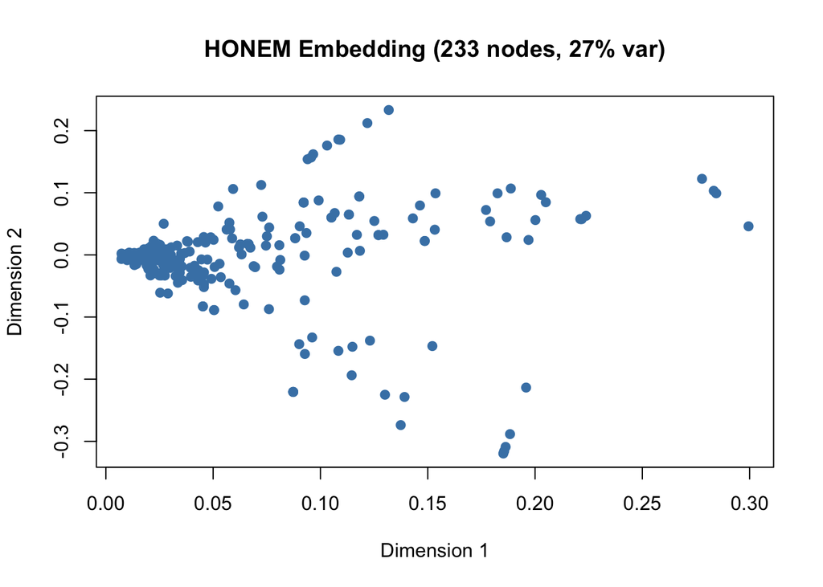

```r
plot(em, dims = c(1, 2))
```

### The states the embedding sits over

The embedding has one row per higher-order *node* — 233 of them. That is far too many to draw: `splot(hon)` is an unreadable hairball, and it is the wrong picture anyway, because what the coordinates are relative to is the nine underlying states. Draw those.

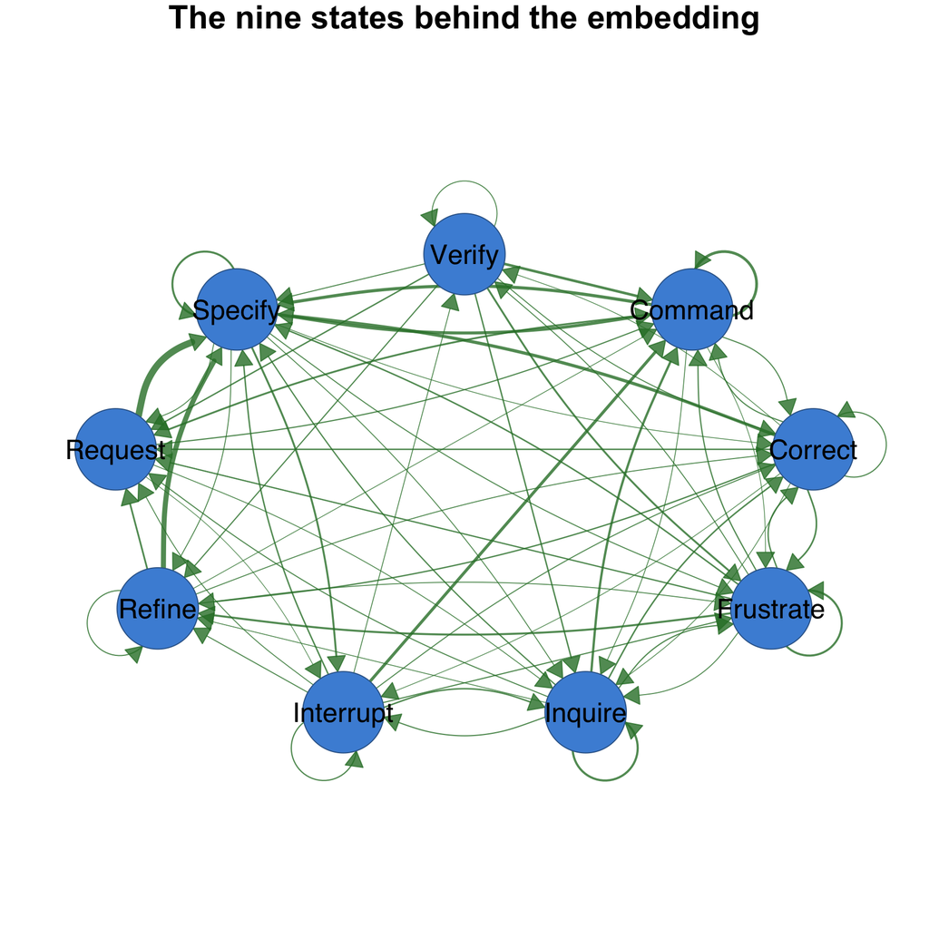

```r
net1 <- build_hon(human_long, action = "code", actor = "session_id",
                  time = "timestamp", max_order = 1, min_freq = 5)
splot(net1, minimum = 0.05, title = "The nine states behind the embedding")
```

Every point in the scatter above is a *context over these nine states* — `Command`, `Command -> Command`, `Command -> Command -> Correct` are three separate rows of the embedding and three separate paths through this graph.

### What an embedding is not

An embedding is a *representation*, not a result. Nothing above is a statistical claim: there are no p-values, no intervals, and the coordinates are only identified up to sign and rotation. Two runs on the same input agree exactly, but a change in `dim` or `max_power` produces a different space, not a rescaled one.

Use it as input to something that does make claims — and if the question is “which actions matter”, `hon_centrality()` answers it directly and interpretably instead.

### What to do next

- **`build_hon()`** — the network this verb consumes. The embedding inherits every choice made there, `min_freq` especially.
- **`hon_centrality()`** — an interpretable ranking rather than a latent space.
- **`hypergraph_cluster()`** — if the goal is grouping rather than coordinates.

### References

- Saebi, M., Ciampaglia, G. L., Kaplan, L. M., & Chawla, N. V. (2020). HONEM: Learning embedding for higher order networks. *Big Data*, 8(4), 255-269.
- Xu, J., Wickramarathne, T. L., & Chawla, N. V. (2016). Representing higher-order dependencies in networks. *Science Advances*, 2(5), e1600028.

## Higher-order centrality: ranking actions a first-order network cannot rank

### The analytic question

Which actions are central to human–AI pair-programming sessions? The usual instrument is a centrality measure on the transition network: build the network of what-follows-what, run PageRank, read off the ranking.

That instrument fails on these data, and it fails in an instructive way. This tutorial shows why, and what a higher-order network recovers. `hon_centrality()` computes centralities on the higher-order topology — where a node is not a state but *a state together with the memory of how it was reached* — and projects them back onto the states, following Scholtes, Wider & Garas (2016). The implementation follows pathpy 2.2.0, that paper’s reference implementation, generalized to the variable-order networks `build_hon()` produces.

The data are `human_long`, bundled with honets: 10,796 coded human turns from 429 sessions, nine action codes.

```r
library(honets)
```

```r
library(cograph)
```

### The first-order network has nothing to say

```r
fo <- build_hon(human_long, action = "code", actor = "session_id",
                time = "timestamp", max_order = 1, min_freq = 5)
fo
```

```
Higher-Order Network (HON)
  Nodes:        9 (9 first-order states)
  Edges:        81
  Max order:    1 (requested 1)
  Min freq:     5
  Trajectories: 425
```

```r
hon_centrality(fo)
```

```
      state  pagerank betweenness closeness
1   Command 0.1111111           0         8
2   Correct 0.1111111           0         8
3 Frustrate 0.1111111           0         8
4   Inquire 0.1111111           0         8
5 Interrupt 0.1111111           0         8
6    Refine 0.1111111           0         8
7   Request 0.1111111           0         8
8   Specify 0.1111111           0         8
9    Verify 0.1111111           0         8
```

Every measure returns the same value for all nine actions: PageRank exactly 1/9, closeness exactly 8, betweenness exactly 0. This is not a numerical accident. With 10,796 turns spread over nine codes, *every one of the 81 possible transitions occurs at least five times*, so the first-order network is the complete digraph on nine nodes. Every node has in-degree nine, which forces PageRank to be uniform; every pair of states is one step apart, which forces closeness to be uniform and betweenness to be zero, because a one-step path has no intermediate node.

The conclusion is decisive and negative: on data this dense, the first-order network is structurally incapable of ranking the actions. No choice of centrality measure repairs it — the information is not in the topology.

### The higher-order network ranks them

```r
hon <- build_hon(human_long, action = "code", actor = "session_id",
                 time = "timestamp", max_order = 3, min_freq = 5)
hon
```

```
Higher-Order Network (HON)
  Nodes:        233 (9 first-order states)
  Edges:        819
  Max order:    3 (requested 3)
  Min freq:     5
  Trajectories: 425
```

```r
hon_centrality(hon, type = "pagerank")
```

```
      state   pagerank
1   Command 0.18365067
2   Correct 0.07833723
3 Frustrate 0.10421334
4   Inquire 0.10991607
5 Interrupt 0.06438203
6    Refine 0.08850329
7   Request 0.09503177
8   Specify 0.23396968
9    Verify 0.04199591
```

The same nine actions, now ranked over a 5.6-fold range: Specify holds 23.4% of the flow, Command 18.4%, down to Verify at 4.2%. The topology that produced this has 233 nodes rather than 9 — the extra 224 are memory contexts such as `Specify -> Command`, each carrying its own distinct continuation distribution.

The ranking exists because the *contexts* differ, even though the states do not. Where the first-order network sees nine interchangeable hubs, the higher-order network sees which of them recur inside the heavily travelled contexts. Specify and Command lead because the flow keeps returning to them along many distinct memory paths; Verify is visited rarely and from few contexts.

### Seeing the ranking

Two pictures, and the choice between them is the whole point of this vignette.

First the network that cannot rank. `fo` is the complete digraph on nine states — every pair one step apart, every node the same degree. The figure shows why no centrality measure can separate these actions: there is no structure to separate them by.

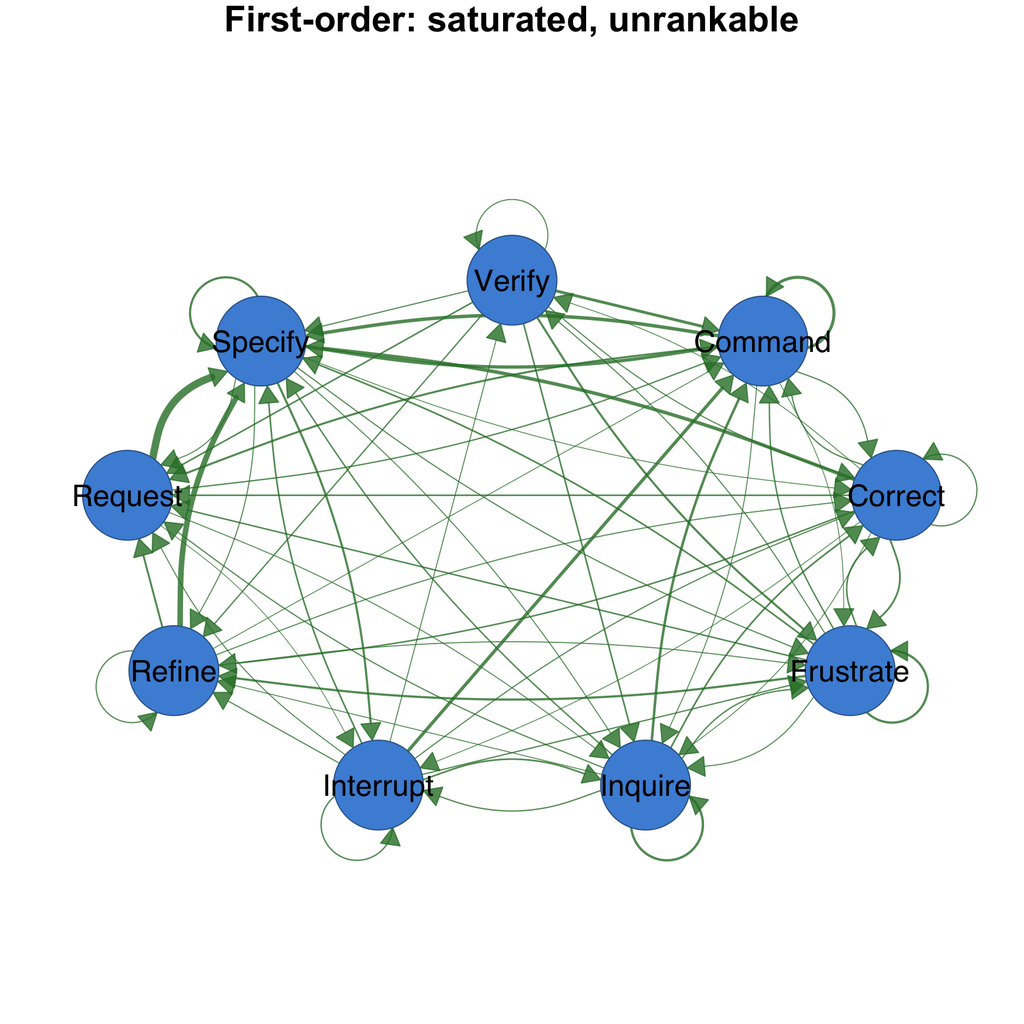

```r
splot(fo, minimum = 0.05, title = "First-order: saturated, unrankable")
```

Then the ranking itself. Note what is **not** plotted here: the higher-order network has 233 nodes and drawing it is an unreadable hairball. `hon_centrality()` already projects onto the nine states, so the figure is of its tidy return — nine rows, one per action.

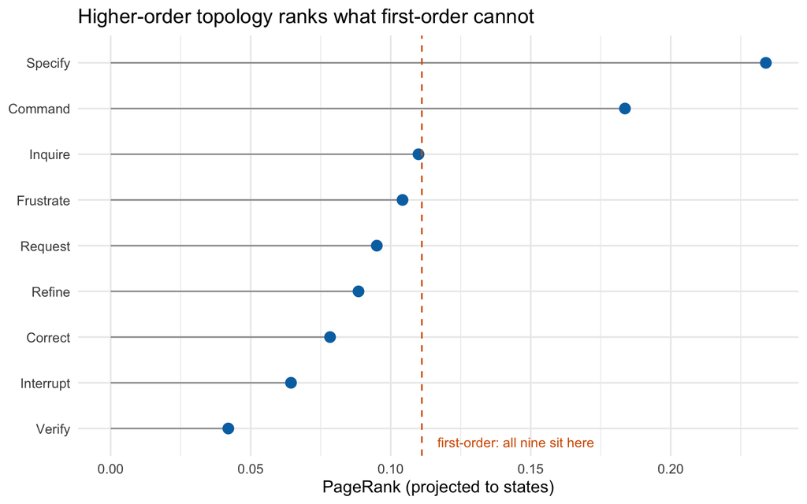

```r
pr <- hon_centrality(hon, type = "pagerank", sort_by = "pagerank")
pr$state <- factor(pr$state, levels = rev(pr$state))
ggplot2::ggplot(pr, ggplot2::aes(x = pagerank, y = state)) +
  ggplot2::geom_segment(ggplot2::aes(x = 0, xend = pagerank,
                                     yend = state),
                        colour = "#999999", linewidth = 0.5) +
  ggplot2::geom_point(size = 3.2, colour = "#0072B2") +
  ggplot2::geom_vline(xintercept = 1 / nrow(pr), linetype = "dashed",
                      colour = "#D55E00") +
  ggplot2::annotate("text", x = 1 / nrow(pr), y = 0.7, hjust = -0.1,
                    label = "first-order: all nine sit here",
                    colour = "#D55E00", size = 3.4) +
  ggplot2::labs(x = "PageRank (projected to states)", y = NULL,
                title = "Higher-order topology ranks what first-order cannot") +
  ggplot2::theme_minimal(base_size = 12)
```

The dashed line is 1/9 — where the first-order network puts every action. The higher-order reading spreads them over a 5.6-fold range.

### Where the ranking comes from

Setting `project = FALSE` reports the centralities of the higher-order nodes themselves — that is, of the contexts rather than the states.

```r
hon_centrality(hon, type = "pagerank", project = FALSE,
               sort_by = "pagerank", top = 8)
```

```
                           node order   pagerank
1            Specify -> Command     2 0.03480103
2            Specify -> Specify     2 0.02101455
3            Command -> Command     2 0.02085538
4            Command -> Specify     2 0.01991084
5             Refine -> Specify     2 0.01536272
6 Inquire -> Command -> Command     3 0.01244368
7            Inquire -> Command     2 0.01232826
8            Request -> Inquire     2 0.01182165
```

The single most central object in these sessions is not an action but a context: `Specify -> Command`, holding 3.5% of the flow on its own — more than three times any individual first-order node. Below it sit `Specify -> Specify` and `Command -> Command`, the two self-repetition contexts, and a third-order context, `Inquire -> Command -> Command`, already appears in the top eight. Specification followed by commanding is the load-bearing pattern of this corpus, and it is invisible to any first-order summary, which can only report that Specify and Command are both frequent.

### Does the projection choice drive the ranking?

A higher-order node spans several states, so its PageRank has to be distributed among them. The default, `"scaled"`, splits it equally (preserving total mass); `"last"` assigns it entirely to the state actually occupied.

```r
scaled <- hon_centrality(hon, type = "pagerank", projection = "scaled")
last <- hon_centrality(hon, type = "pagerank", projection = "last")
data.frame(state = scaled$state, scaled = scaled$pagerank,
           last = last$pagerank)
```

```
      state     scaled       last
1   Command 0.18365067 0.18375557
2   Correct 0.07833723 0.07896900
3 Frustrate 0.10421334 0.09997477
4   Inquire 0.10991607 0.10706961
5 Interrupt 0.06438203 0.06198670
6    Refine 0.08850329 0.09076024
7   Request 0.09503177 0.09258325
8   Specify 0.23396968 0.24412812
9    Verify 0.04199591 0.04077275
```

The two agree to within about one percentage point on every action, and the ordering is identical. The ranking is therefore a property of the higher-order topology, not of the projection rule, and can be reported without a projection caveat.

### Betweenness and closeness need a sparser network

Both measures were degenerate on the first-order network. They stay degenerate on the full higher-order network, and for the same reason:

```r
hon_centrality(hon, type = c("betweenness", "closeness"))
```

```
      state betweenness closeness
1   Command           0         8
2   Correct           0         8
3 Frustrate           0         8
4   Inquire           0         8
5 Interrupt           0         8
6    Refine           0         8
7   Request           0         8
8   Specify           0         8
9    Verify           0         8
```

The projection maps every ordered pair of states to a one-step path, because a second-order node exists for essentially every pair. With no intermediate nodes on any shortest path, betweenness is zero everywhere and closeness is a constant 8. Unlike PageRank, these two measures depend only on the *reachability* structure, and reachability here is saturated.

Raising `min_freq` keeps only the well-evidenced transitions, which restores a topology with genuine distances:

```r
sparse <- build_hon(human_long, action = "code", actor = "session_id",
                    time = "timestamp", max_order = 3, min_freq = 80)
sparse
```

```
Higher-Order Network (HON)
  Nodes:        17 (9 first-order states)
  Edges:        49
  Max order:    3 (requested 3)
  Min freq:     80
  Trajectories: 425
```

```r
hon_centrality(sparse, type = c("betweenness", "closeness"))
```

```
      state betweenness closeness
1   Command  12.4166667  7.000000
2   Correct   1.2500000  6.000000
3 Frustrate   1.5833333  6.000000
4   Inquire   0.6666667  5.500000
5 Interrupt   0.0000000  4.333333
6    Refine   0.0000000  5.333333
7   Request   0.8333333  6.500000
8   Specify  22.2500000  7.500000
9    Verify   0.0000000  5.000000
```

On the 17-node network of transitions seen at least 80 times, the measures separate sharply. Specify brokers 22.3 shortest paths and Command 12.4, while Interrupt, Refine and Verify broker none at all: the well-evidenced routes between actions run through the two directive codes, and the remaining actions sit at the ends of those routes rather than along them. Closeness ranks the same two highest (7.5 and 7.0), confirming that they are also the easiest actions to reach.

Note what this costs: the sparse network describes only the strongest transitions, so it answers a narrower question than the PageRank analysis above. Report the threshold with the result.

### When to use which

- **`hon_centrality(hon)`** — the question is which states carry flow, and the sequences have memory. PageRank is the measure to trust on dense data; betweenness and closeness require a topology with real distances, so check for saturation (all-zero betweenness, constant closeness) before interpreting them.
- **`project = FALSE`** — the question is which *contexts* dominate. Often the more useful table, and the only place where a pattern like `Specify -> Command` can appear at all.
- **`build_hon(max_order = 1)`** — the first-order baseline. Always run it: the gap between it and the higher-order ranking is the evidence that memory matters, and if there is no gap, the simpler model should be reported.
- **`bootstrap_hon()`** — before reporting a higher-order ranking, check that the rules producing it survive resampling.
- **`markov_order_test()`** — the prior question of whether memory exists at all, as a single global test.

### References

- Scholtes, I., Wider, N., & Garas, A. (2016). Higher-order aggregate networks in the analysis of temporal networks: path structures and centralities. *The European Physical Journal B*, 89, 61.
- Xu, J., Wickramarathne, T. L., & Chawla, N. V. (2016). Representing higher-order dependencies in networks. *Science Advances*, 2(5), e1600028.
- Scholtes, I. (2017). When is a network a network? Multi-order graphical model selection in pathways and temporal networks. *KDD 2017*.

## Are the higher-order rules real? Bootstrap and permutation inference for HONs

### The analytic question

A higher-order network promotes a context to a rule — *after Specify → Command, the next action follows a different distribution than after Command alone* — whenever a divergence criterion is met in the sample (Xu, Wickramarathne & Chawla 2016). The criterion is a point decision on one dataset. Two questions have to be answered before such rules are reported as findings:

1. **Stability.** Would the same rules be extracted from another sample of the same process? `bootstrap_hon()` resamples sequences with replacement and reports, for every rule, the fraction of replicates that re-extract it (*support*) and a percentile confidence interval for its conditional probability.
2. **Difference.** Do two cohorts follow different rules? `compare_hon()` tests every pooled rule edge with a permutation null and aggregates a global test, with Benjamini–Hochberg control over the per-edge multiplicity.

Both verbs precompute per-sequence counts once and rebuild every replicate from reweighted counts, so their cost does not grow with sequence length re-scans, and their results are identical in serial and parallel runs under the same seed.

The data are `human_long`, bundled with honets: 10,796 coded human turns from 429 human–AI pair-programming sessions; each session’s ordered codes form one categorical sequence.

```r
library(honets)
```

### Which rules survive resampling?

Rules are extracted up to order 3, requiring each transition to occur at least 5 times, and every rule is re-examined in 500 bootstrap resamples of the sessions.

```r
bs <- bootstrap_hon(human_long, action = "code", actor = "session_id",
                    time = "timestamp", n_boot = 500, max_order = 3,
                    min_freq = 5, seed = 11, parallel = TRUE, n_cores = 2)
bs
```

```
HON bootstrap: 829 rule edges (748 higher-order) from 425 sequences
  500 replicates, 95% percentile CIs
  Higher-order rule support: min 0.35, median 1.00, max 1.00
  Tidy table: as.data.frame(x); higher-order only: as.data.frame(x, order_min = 2)
```

```r
summary(bs)
```

[output not shown]

The 425 usable sessions yield 829 rule edges: 81 first-order, 451 second-order, 297 third-order. The summary separates the layers sharply. The second-order layer is solid — mean support 0.995, and even its least stable rule is re-extracted in 89.8% of replicates. The third-order layer is mixed: mean support 0.85, minimum 0.35, and its intervals are wide (mean width 0.70 against 0.20 at order 2). The conclusion is directional: the second-order structure of these sessions can be reported as a whole; third-order claims need the per-rule filter below.

```r
as.data.frame(bs, order_min = 2, min_support = 0.9,
              sort_by = "count", top = 10)
```

```
                            from        to order count probability  ci_lower
1             Specify -> Command   Specify     2   284   0.3901099 0.3576493
2             Command -> Request   Specify     2   231   0.7674419 0.7229390
3             Specify -> Command   Request     2   199   0.2733516 0.2412228
4             Request -> Specify Interrupt     2   189   0.3258621 0.2776583
5  Specify -> Command -> Request   Specify     3   181   0.9679144 0.9073834
6             Command -> Command   Command     2   177   0.3881579 0.3365444
7             Command -> Specify Interrupt     2   149   0.2769517 0.2384711
8  Command -> Request -> Specify Interrupt     3   136   0.6098655 0.5428544
9             Specify -> Request   Specify     2   128   0.6597938 0.6034591
10            Specify -> Specify   Specify     2   123   0.2662338 0.2316099
    ci_upper support n_boot_used
1  0.4254156   1.000         500
2  0.8412833   0.988         500
3  0.3088498   1.000         500
4  0.3756526   1.000         500
5  1.0000000   0.900         500
6  0.4357474   1.000         500
7  0.3201072   1.000         500
8  0.6915423   0.938         500
9  0.7556596   0.980         500
10 0.2976057   1.000         500
```

604 of the 748 higher-order rules pass a 0.9 support floor; the table shows the ten most frequent. The strongest patterns are the directive loop seen from different depths: after `Command -> Request` the next action is Specify with probability 0.77 (CI 0.72–0.84), and the third-order context `Specify -> Command -> Request` sharpens this to 0.97 (CI 0.91–1.00, support 0.90). History genuinely narrows the prediction — the deeper context nearly determines the next action, and the bootstrap says that narrowing is not a sampling artifact.

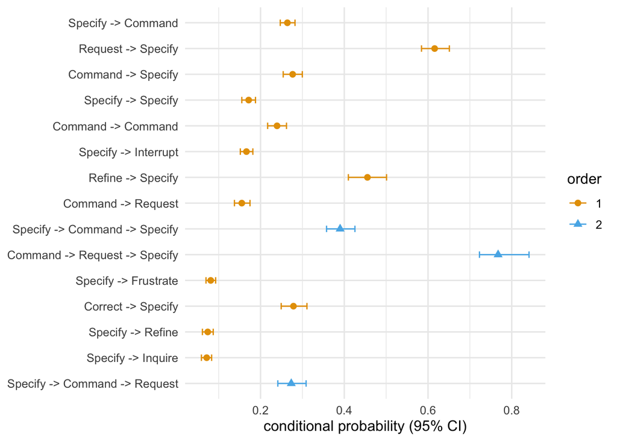

```r
plot(bs, top = 15)
```

### Did the rules change between the early and late period?

The sessions span 2026-02-05 to 2026-03-08. Splitting the events at the median date gives two cohorts of comparable size (a session straddling the cutoff contributes its early turns to the first cohort and its late turns to the second).

```r
early <- subset(human_long, session_date < "2026-02-21")
late  <- subset(human_long, session_date >= "2026-02-21")
cmp <- compare_hon(early, late, action = "code", actor = "session_id",
                   time = "timestamp", n_perm = 500, max_order = 3,
                   min_freq = 5, seed = 12, parallel = TRUE, n_cores = 2,
                   names = c("early", "late"))
cmp
```

```
HON comparison: early (210 sequences) vs late (217 sequences)
  828 pooled rule edges, 500 permutations
  Global weighted |diff|: 0.0875, p = 0.001996
  Significant edges (BH, alpha = 0.05): 0
  Tidy table: as.data.frame(x); significant only: as.data.frame(x, significant = TRUE)
```

```r
summary(cmp)
```

The two results disagree on purpose, and reading them together is the point of the design. The global test is unambiguous: the pooled-count-weighted mean absolute difference is 0.0875, and only 1 of 501 permutations reaches it (p = 0.002) — the rule structure did shift between the periods. Yet not a single one of the 828 edges is individually significant after Benjamini–Hochberg adjustment. The shift is *diffuse*: many small, consistent differences spread across the rule set, none large enough to survive 828-way multiplicity on its own. The extreme per-edge differences (absolute difference 1.0 at orders 2–3) are contexts observed in only one period with small counts — exactly the edges a permutation null neutralizes.

The decisive report is therefore: the interaction rules changed over time as a whole, and no single rule should be named as the locus of that change. Naming one anyway — picking the largest difference and reporting it despite its adjusted p-value — is the multiple-testing error this verb’s two-level design exists to prevent.

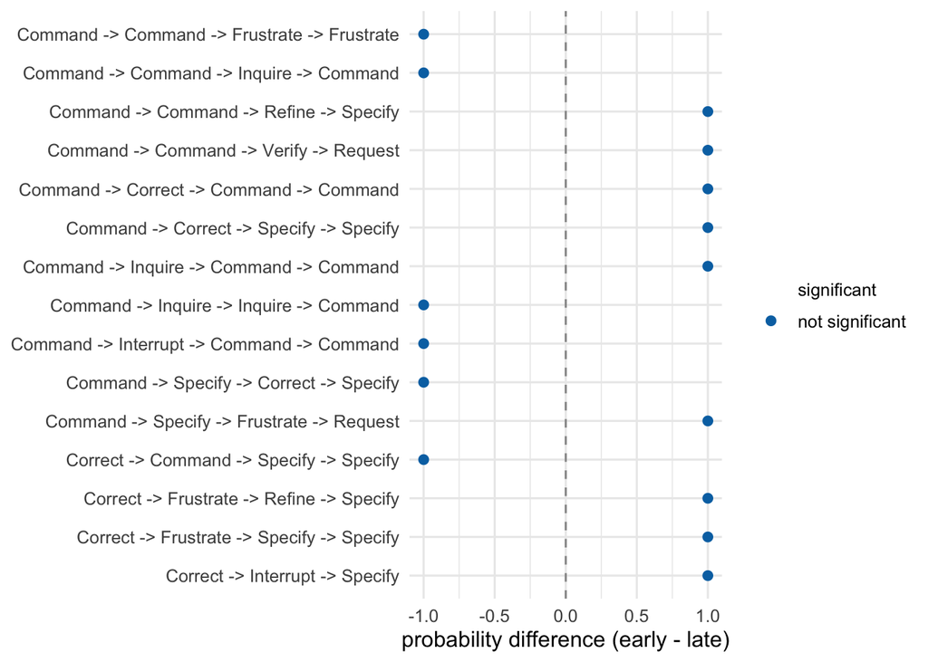

```r
plot(cmp, top = 15)
```

The difference plot confirms the reading: the largest differences all plot in the not-significant encoding, and no edge separates from the pack.

### When to use which

- **`bootstrap_hon()`** — one cohort, and the question is whether the extracted rules and their probabilities are stable enough to report. Filter with `as.data.frame(x, order_min = 2, min_support = 0.9)` before citing individual higher-order rules; report interval widths, not just point probabilities.
- **`compare_hon()`** — two cohorts, and the question is whether the rule structure differs. Read the global test first; per-edge findings only from the BH-adjusted column. A significant global with no significant edges is a finding, not a failure: the difference is distributed.
- **`markov_order_test()`** — the prior, coarser question: is there any memory beyond order 1 at all, as a single global decision.
- **`path_dependence()`** — a descriptive per-context diagnostic of where memory concentrates, without inference; useful for choosing contexts to examine before the bootstrap.

### References

- Xu, J., Wickramarathne, T. L., & Chawla, N. V. (2016). Representing higher-order dependencies in networks. *Science Advances*, 2(5), e1600028.
- Efron, B., & Tibshirani, R. J. (1993). *An Introduction to the Bootstrap*. Chapman & Hall.
- Good, P. (2005). *Permutation, Parametric and Bootstrap Tests of Hypotheses* (3rd ed.). Springer.
- Benjamini, Y., & Hochberg, Y. (1995). Controlling the false discovery rate. *JRSS B*, 57(1), 289–300.